# Assignment MP2

Tanush Shetty

26/10/2024

```r
# Set a CRAN mirror
options(repos = c(CRAN = "https://cran.r-project.org"))

install.packages("pacman")
library(pacman)
pacman::p_load(pacman, dplyr, forecast, fpp, fpp2, readr)

data <- read.csv("C:/Users/tanus/Downloads/BF assign 7 mp2/insurance.csv")

head(data)
```

```
##   X   Quotes TV.advert
## 1 1 12.97065  7.212725
## 2 2 15.38714  9.443570
## 3 3 13.22957  7.534250
## 4 4 12.97065  7.212725
## 5 5 15.38714  9.443570
## 6 6 11.72288  6.415215
```

```r
str(data)
```

```
## 'data.frame':    40 obs. of  3 variables:
##  $ X        : int  1 2 3 4 5 6 7 8 9 10 ...
##  $ Quotes   : num  13 15.4 13.2 13 15.4 ...
##  $ TV.advert: num  7.21 9.44 7.53 7.21 9.44 ...
```

1. Create Timeseries

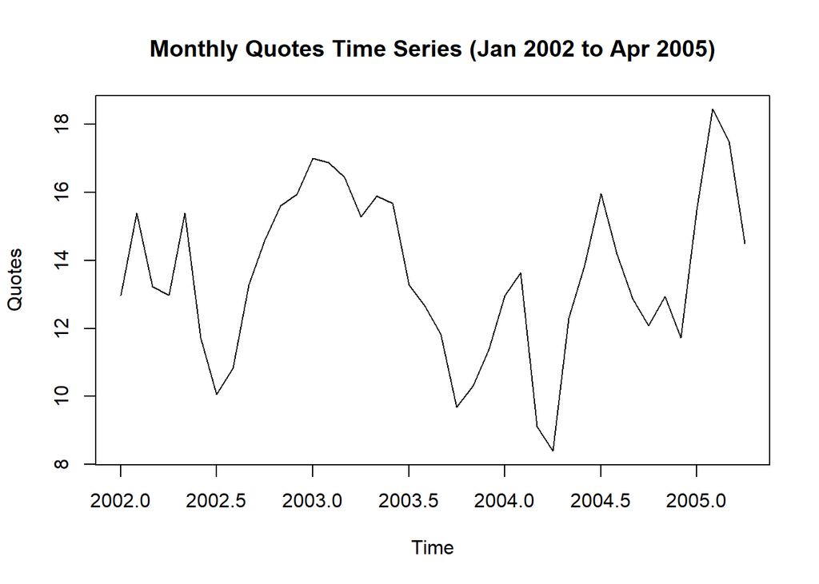

```r
ts_data = ts(data$Quotes, frequency = 12, start = c(2002,1), end=c(2005,4))

plot(ts_data, main = "Monthly Quotes Time Series (Jan 2002 to Apr 2005)", ylab = "Quotes", xlab = "Time")
```

2. Verify how much history to include in your analysis.

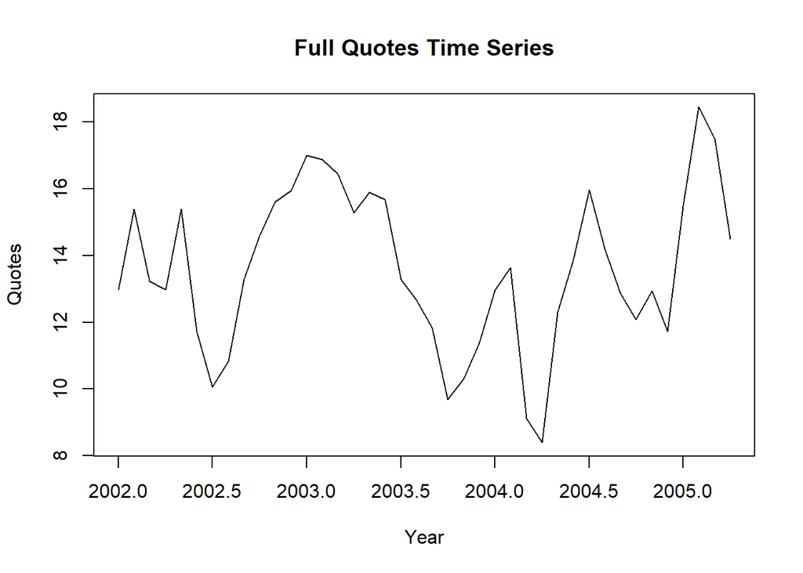

```r
# Visualize the full time series
plot(ts_data, main = "Full Quotes Time Series", ylab = "Quotes", xlab = "Year")
```

```r
# Visualize recent years only
recent_data <- window(ts_data, start = max(time(ts_data)) - 9)
```

[figure not shown]

```r
plot(recent_data, main = "Recent 10 Years Quotes Time Series", ylab = "Quotes", xlab = "Year")
```

3. Hypothesize if the dataset has trend, seasonality, or both. Looking at the graph, there doesn’t appear to be a clear upward or downward trend in the dataset. The values fluctuate over time, but there isn’t a consistent increase or decrease across the years. This suggests the data may lack a long-term trend. There is some indication of recurring fluctuations, with peaks and valleys appearing at semi-regular intervals. This could suggest seasonal effects, although, with only a few cycles visible, it’s difficult to confirm without additional data or analysis.